# Scraping table data

Pablo Barbera

### Scraping web data in table format

We will start by loading the `rvest` package, which will help us scrape data from the web.

```r
library(rvest)
```

Here we will learn how to scrape the number of new social security number holders by year in the US, and then the collected data so that we can generate a plot showing the evolution in this variable over time.

The first step is to read the html code from the website we want to scrape, using the `read_html()` function. If we want to see the html in text format, we can then use `html_text()`.

```r
url <- "https://www.ssa.gov/oact/babynames/numberUSbirths.html"
html <- read_html(url) # reading the html code into memory
html # not very informative
```

```
## {html_document}
## <html class="no-js" lang="en">
## [1] <head>\n<meta http-equiv="Content-Type" content="text/html; charset=UTF-8 ...
## [2] <body>\r\n  <!-- BANNER -->\r\n  <aside class="accessibility" id="accessi ...
```

```r
substr(html_text(html), 1, 1000) # first 1000 characters
```

```
## [1] "Social Security number holders\r\ntd,th {text-align:center}\r\n\r\n  \r\n  Skip to content\n  \n    Coronavirus (COVID-19) Updates\n    \n\n\n  Learn about Emergency Assistance for Homeowners and Renters\n\n Social Security SEARCH MENU LANGUAGES SIGN IN/UP \r\n        Social Security number …
```

```r
tab <- html_table(html, fill=TRUE)
str(tab)
```

```
## List of 1
##  $ :'data.frame':    141 obs. of  4 variables:
##   ..$ Year of birth: int [1:141] 1880 1881 1882 1883 1884 1885 1886 1887 1888 1889 ...
##   ..$ Male         : chr [1:141] "118,399" "108,280" "122,031" "112,475" ...
##   ..$ Female       : chr [1:141] "97,606" "98,855" "115,694" "120,059" ...
##   ..$ Total        : chr [1:141] "216,005" "207,135" "237,725" "232,534" ...
```

```r
pop <- tab[[1]]
```

Now let’s clean the data so that we can use it for our analysis. We need to convert the population values into a numeric format, which requires deleting the commas. We will also change the variable names so that it’s easier to work with them.

```r
pop$Male <- as.numeric(gsub(",", "", pop$Male))
pop$Female <- as.numeric(gsub(",", "", pop$Female))
names(pop) <- c("year", "male", "female", "total")
```

And now we can plot to see how the number of people applying for a Social Security Number in the US has increased over time.

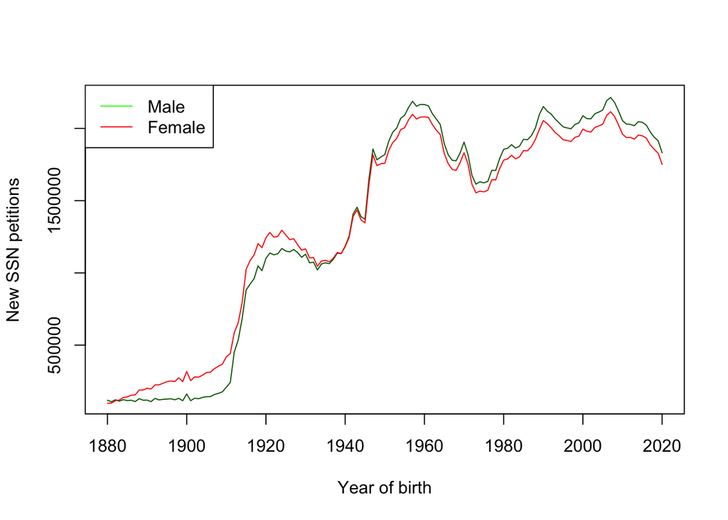

```r
plot(pop$year, pop$male, xlab="Year of birth", ylab="New SSN petitions",
      col="darkgreen", type="l")
lines(pop$year, pop$female, col="red")
legend(x="topleft", c("Male", "Female"), lty=1, col=c("green", "red"))
```

### Scraping web data in table format: a more advanced example

When there are multiple tables on the website, scraping them becomes a bit more complicated. Let’s work through a common case scenario: scraping a table from Wikipedia with a list of the most populated cities in the United States.

```r
url <- 'https://en.wikipedia.org/wiki/List_of_United_States_cities_by_population'
html <- read_html(url)
tables <- html_table(html, fill=TRUE)
length(tables)
```

```
## [1] 15
```

The function now returns 15 different tables. I had to use the option `fill=TRUE` because some of the tables appear to have incomplete rows.

In this case, identifying the part of the html code that contains the table is a better approach. To do so, let’s take a look at the source code of the website. In Google Chrome, go to *View* > *Developer* > *View Source*. All browsers should have similar options to view the source code of a website.

```r
wiki <- html_nodes(html, '.wikitable')
length(wiki)
```

```
## [1] 8
```

There are 8 tables in total, and we will extract the second one.

```r
pop <- html_table(wiki[[2]])
str(pop)
```

```
## 'data.frame':    326 obs. of  11 variables:
##  $ 2020rank               : int  1 2 3 4 5 6 7 8 9 10 ...
##  $ City                   : chr  "New York[d]" "Los Angeles" "Chicago" "Houston" ...
##  $ State[c]               : chr  "New York" "California" "Illinois" "Texas" ...
##  $ 2020census             : chr  "8,804,190" "3,898,747" "2,746,388" "2,304,580" ...
##  $ 2010census             : chr  "8,175,133" "3,792,621" "2,695,598" "2,100,263" ...
##  $ Change                 : chr  "+7.69%" "+2.80%" "+1.88%" "+9.73%" ...
##  $ 2016 land area         : chr  "301.5 sq mi" "468.7 sq mi" "227.3 sq mi" "637.5 sq mi" ...
##  $ 2016 land area         : chr  "780.9 km2" "1,213.9 km2" "588.7 km2" "1,651.1 km2" ...
##  $ 2016 population density: chr  "28,317/sq mi" "8,484/sq mi" "11,900/sq mi" "3,613/sq mi" ...
##  $ 2016 population density: chr  "10,933/km2" "3,276/km2" "4,600/km2" "1,395/km2" ...
##  $ Location               : chr  ".mw-parser-output .geo-default,.mw-parser-output .geo-dms,.mw-parser-output .geo-dec{display:inline}.mw-parser-"| __truncated__ "34°01′N 118°25′W / 34.01°N 118.41°W / 34.01; -118.41 (2 Los Angeles)" "41°50′N 87°41′W / 41.83°N 87.68°W / 41.83; -87.68 (3 Chicago)" …
```

As in the previous case, we still need to clean the data before we can use it. For this particular example, let’s see if this dataset provides evidence in support of [Zipf’s law for population ranks](https://en.wikipedia.org/wiki/Zipf%27s_law).

We’ll use regular expressions to remove endnotes and commas in the population numbers, and clean the variable names. (We’ll come back to this later in the course.)

```r
pop$city_name <- gsub('\\[.*\\]', '', pop$City)
pop$population <- pop[,"2020census"]
pop$population <- as.numeric(gsub(",", "", pop$population))
pop$rank <- pop[,"2020rank"]
pop <- pop[,c("rank", "population", "city_name")]
```

Now we’re ready to generate the figure:

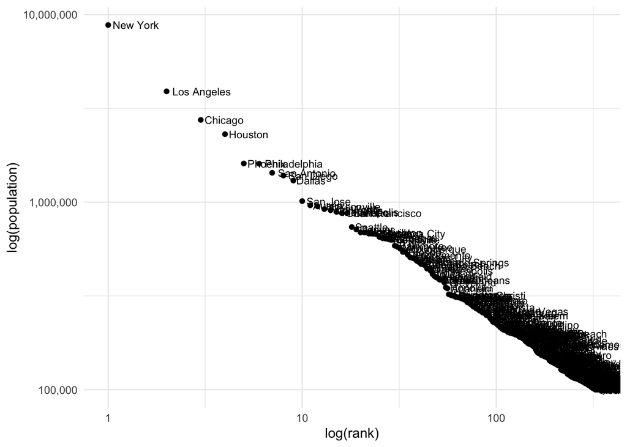

```r
library(ggplot2)
p <- ggplot(pop, aes(x=rank, y=population, label=city_name))
pq <- p + geom_point() + geom_text(hjust=-.1, size=3) +
    scale_x_log10("log(rank)") +
  scale_y_log10("log(population)", labels=scales::comma) +
  theme_minimal()
pq
```

We can also check if this distribution follows Zipf’s law estimating a log-log regression.

```r
lm(log(rank) ~ log(population), data=pop)
```

```
##
## Call:
## lm(formula = log(rank) ~ log(population), data = pop)
##
## Coefficients:
##     (Intercept)  log(population)
##           21.64            -1.38
```